# Bellabeat Analysis

Erick Smith

2023-04-25

## **Case study: FitBit Tracker Data For Bellabeat in R**

Hello everyone, this case of study show you what are some trends inside the products of Bellabeat company.

## **About the company**

Urška Sršen and Sando Mur founded Bellabeat, a high-tech company that manufactures health-focused smart products. Sršen used her background as an artist to develop beautifully designed technology that informs and inspires women around the world. Collecting data on activity, sleep, stress, and reproductive health has allowed Bellabeat to empower women with knowledge about their own health and habits.

### Products

Bellabeat launched multiple products, but for my Case Study I will choose only wellness tracker. Wearable trackers are an increasingly popular tool among healthy adults and are used to facilitate self-monitoring of physical activity.

- Bellabeat app: The Bellabeat app provides users with health data related to their activity, sleep, stress, menstrual cycle, and mindfulness habits. This data can help users better understand their current habits and make healthy decisions. The Bellabeat app connects to their line of smart wellness products.
- Leaf: Bellabeat’s classic wellness tracker can be worn as a bracelet, necklace, or clip. The Leaf tracker connects to the Bellabeat app to track activity, sleep, and stress.
- Time: This wellness watch combines the timeless look of a classic timepiece with smart technology to track user activity, sleep, and stress. The Time watch connects to the Bellabeat app to provide you with insights into your daily wellness.
- Spring: This is a water bottle that tracks daily water intake using smart technology to ensure that you are appropriately hydrated throughout the day. The Spring bottle connects to the Bellabeat app to track your hydration levels.
- Bellabeat membership: Bellabeat also oﬀers a subscription-based membership program for users. Membership gives users 24/7 access to fully personalized guidance on nutrition, activity, sleep, health and beauty, and mindfulness based on their lifestyle and goals.

## **Ask**

Identifying the problem of the stakeholders, they need to guide a marketing strategy using product of Bellabeat. In this analysis I will answer this questions:

1. What are some trends in smart device usage?
2. How could these trends apply to Bellabeat customers?
3. How could these trends help inﬂuence Bellabeat marketing strategy?

## **Prepare**

I use public data that explores smart device users’ daily habits.Speciﬁc data set:

The data are including:

- Minute-level output for physical activity.
- Heart rate.
- Sleep monitoring.
- Daily activity.
- Steps.
- Heart rate.

## **Process**

### **Loading Packages**

```r
#install.packages("tidyverse")
library(tidyverse)
library(dplyr)
```

### **Loading Data**

```r
d_activity <- read_csv("C:\\Users\\Usuario\\Documents\\Cursos DATA SCIENCE\\Google Analitics Certificate\\8.-\\Data set\\Fitabase Data 4.12.16-5.12.16\\dailyActivity_merged.csv")
hartrate <- read_csv("C:\\Users\\Usuario\\Documents\\Cursos DATA SCIENCE\\Google Analitics Certificate\\8.-\\Data set\\Fitabase Data 4.12.16-5.12.16\\heartrate_seconds_merged.csv")
sleep_day <- read_csv("C:\\Users\\Usuario\\Documents\\Cursos DATA SCIENCE\\Google Analitics Certificate\\8.-\\Data set\\Fitabase Data 4.12.16-5.12.16\\sleepDay_merged.csv")
sleep <- read_csv("C:\\Users\\Usuario\\Documents\\Cursos DATA SCIENCE\\Google Analitics Certificate\\8.-\\Data set\\Fitabase Data 4.12.16-5.12.16\\minuteSleep_merged.csv")
steps_narrow <- read_csv("C:\\Users\\Usuario\\Documents\\Cursos DATA SCIENCE\\Google Analitics Certificate\\8.-\\Data set\\Fitabase Data 4.12.16-5.12.16\\minuteStepsNarrow_merged.csv")
intensities_narrow <- read_csv("C:\\Users\\Usuario\\Documents\\Cursos DATA SCIENCE\\Google Analitics Certificate\\8.-\\Data set\\Fitabase Data 4.12.16-5.12.16\\minuteIntensitiesNarrow_merged.csv")
calories_narrow <- read_csv("C:\\Users\\Usuario\\Documents\\Cursos DATA SCIENCE\\Google Analitics Certificate\\8.-\\Data set\\Fitabase Data 4.12.16-5.12.16\\minuteCaloriesNarrow_merged.csv")
weight_login_info <- read_csv("C:\\Users\\Usuario\\Documents\\Cursos DATA SCIENCE\\Google Analitics Certificate\\8.-\\Data set\\Fitabase Data 4.12.16-5.12.16\\weightLogInfo_merged.csv")
```

### **Changing Format (dates)**

```r
# Sleep
sleep$fecha <- as.Date(sleep$date, format = "%m/%d/%Y")
sleep$hora <- format(as.POSIXct(sleep$date, format = "%m/%d/%Y %H:%M:%S"), "%H:%M:%S")



# Calories
calories_narrow$fecha <- as.Date(calories_narrow$ActivityMinute, format = "%m/%d/%Y")
calories_narrow$hora <- format(as.POSIXct(calories_narrow$ActivityMinute, format = "%m/%d/%Y %H:%M:%S"), "%H:%M:%S")

# Hartrate
hartrate$fecha <- as.Date(hartrate$Time, format = "%m/%d/%Y")
hartrate$hora <- format(as.POSIXct(hartrate$Time, format = "%m/%d/%Y %H:%M:%S"), "%H:%M:%S")


# Intensities
intensities_narrow$fecha <- as.Date(intensities_narrow$ActivityMinute, format = "%m/%d/%Y")
intensities_narrow$hora <- format(as.POSIXct(intensities_narrow$ActivityMinute, format = "%m/%d/%Y %H:%M:%S"), "%H:%M:%S")

# Weight
weight_login_info$fecha <- as.Date(weight_login_info$Date, format = "%m/%d/%Y")
weight_login_info$hora <- format(as.POSIXct(weight_login_info$Date, format = "%m/%d/%Y %H:%M:%S"), "%H:%M:%S")


#Steps - ORIGINAL
steps_narrow$fecha <- as.Date(steps_narrow$ActivityMinute, format = "%m/%d/%Y")
steps_narrow$hora <- format(as.POSIXct(steps_narrow$ActivityMinute, format = "%m/%d/%Y %H:%M:%S"), "%H:%M:%S")
```

```r
steps_filtered <- steps_narrow %>%
                  filter(Steps > 0)
steps_filtered$fecha <- sapply(strsplit(steps_filtered$ActivityMinute, " "), "[[", 1)
steps_filtered$hora <- sapply(strsplit(steps_filtered$ActivityMinute, " "), "[[", 2)
steps_filtered$am_pm <- sapply(strsplit(steps_filtered$ActivityMinute, " "), "[[", 3)
```

### **Number of clients in datasets**

```r
print(paste("Total Customers in Dataset d_activity:", n_distinct(d_activity$Id)))
```

```
## [1] "Total Customers in Dataset d_activity: 33"
```

```r
print(paste("Total Customers in Dataset hartrate:", n_distinct(hartrate$Id)))
```

```
## [1] "Total Customers in Dataset hartrate: 14"
```

```r
print(paste("Total Customers in Dataset sleep_day:", n_distinct(sleep_day$Id)))
```

```
## [1] "Total Customers in Dataset sleep_day: 24"
```

```r
print(paste("Total Customers in Dataset sleep_minutes:", n_distinct(sleep$Id)))
```

```
## [1] "Total Customers in Dataset sleep_minutes: 24"
```

```r
print(paste("Total Customers in Dataset intensities_minutes:", n_distinct(intensities_narrow$Id)))
```

```
## [1] "Total Customers in Dataset intensities_minutes: 33"
```

```r
print(paste("Total Customers in Dataset weight_login_info:", n_distinct(weight_login_info$Id)))
```

```
## [1] "Total Customers in Dataset weight_login_info: 8"
```

```r
print(paste("Total Customers in Dataset calories_minute:", n_distinct(calories_narrow$Id)))
```

```
## [1] "Total Customers in Dataset calories_minute: 33"
```

**Note: The users into the different csv files are not included in all the data sets. Is important to know this problem because can affect directly in the calculations**

### **Missing Users**

```r
usuarios_faltantes_hartrate <- unique(setdiff(d_activity$Id, hartrate$Id))
print(paste("Missing Users in hartrate :", toString(usuarios_faltantes_hartrate)))
```

```
## [1] "Missing Users in hartrate : 1503960366, 1624580081, 1644430081, 1844505072, 1927972279, 2320127002, 2873212765, 3372868164, 3977333714, 4057192912, 4319703577, 4445114986, 4702921684, 6290855005, 7086361926, 8053475328, 8253242879, 8378563200, 8583815059"
```

```r
usuarios_faltantes_sleep_day <- unique(setdiff(d_activity$Id, sleep_day$Id))
print(paste("Missing Users in sleep_day :",toString(usuarios_faltantes_sleep_day)))
```

```
## [1] "Missing Users in sleep_day : 1624580081, 2022484408, 2873212765, 3372868164, 4057192912, 6290855005, 8253242879, 8583815059, 8877689391"
```

```r
usuarios_faltantes_sleep <- unique(setdiff(d_activity$Id, sleep$Id))
print(paste("Missing Users in sleep :", toString(usuarios_faltantes_sleep)))
```

```
## [1] "Missing Users in sleep : 1624580081, 2022484408, 2873212765, 3372868164, 4057192912, 6290855005, 8253242879, 8583815059, 8877689391"
```

```r
usuarios_faltantes_weight_login_info <- unique(setdiff(d_activity$Id, weight_login_info$Id))
print(paste("Missing Users in weight_login_info :", toString(usuarios_faltantes_weight_login_info)))
```

[output not shown]

### **Shearching NaN**

```r
print(paste("NaN values in d_activity :",sum(is.na(d_activity))))
```

```
## [1] "NaN values in d_activity : 0"
```

```r
print(paste("NaN values in hartrate :",sum(is.na(hartrate))))
```

```
## [1] "NaN values in hartrate : 0"
```

```r
print(paste("NaN values in sleep_day :",sum(is.na(sleep_day))))
```

```
## [1] "NaN values in sleep_day : 0"
```

```r
print(paste("NaN values in sleep :",sum(is.na(sleep))))
```

```
## [1] "NaN values in sleep : 0"
```

```r
print(paste("NaN values in steps_narrow :",sum(is.na(steps_narrow))))
```

```
## [1] "NaN values in steps_narrow : 0"
```

```r
print(paste("NaN values in intensities_narrow :",sum(is.na(intensities_narrow))))
```

```
## [1] "NaN values in intensities_narrow : 0"
```

```r
print(paste("NaN values in calories_narrow :",sum(is.na(calories_narrow))))
```

```
## [1] "NaN values in calories_narrow : 0"
```

```r
print(paste("NaN values in weight_login_info :",sum(is.na(weight_login_info))))
```

```
## [1] "NaN values in weight_login_info : 65"
```

### **Duplicates users**

```r
print(paste("Number of  values Dupplicated in d_activity :",sum(duplicated(d_activity))
))
```

```
## [1] "Number of  values Dupplicated in d_activity : 0"
```

```r
print(paste("Number of  values Dupplicated hartrate :",sum(duplicated(hartrate))))
```

```
## [1] "Number of  values Dupplicated hartrate : 0"
```

```r
print(paste("Number of  values Dupplicated sleep_day :",sum(duplicated(sleep_day))
))
```

```
## [1] "Number of  values Dupplicated sleep_day : 3"
```

```r
print(paste("Number of  values Dupplicated sleep :",sum(duplicated(sleep))
))
```

```
## [1] "Number of  values Dupplicated sleep : 543"
```

```r
print(paste("Number of  values Dupplicated steps_narrow :",sum(duplicated(steps_narrow))
))
```

```
## [1] "Number of  values Dupplicated steps_narrow : 0"
```

```r
print(paste("Number of  values Dupplicated in intensities_narrow :",sum(duplicated(intensities_narrow))
))
```

```
## [1] "Number of  values Dupplicated in intensities_narrow : 0"
```

```r
print(paste("Number of  values Dupplicated in calories_narrow :",sum(duplicated(calories_narrow))
))
```

```
## [1] "Number of  values Dupplicated in calories_narrow : 0"
```

```r
print(paste("Number of  values Dupplicated in weight_login_info :",sum(duplicated(weight_login_info))
))
```

```
## [1] "Number of  values Dupplicated in weight_login_info : 0"
```

### **Eliminate duplicate values**

```r
sleep_day_clean <- unique(sleep)
sleep_clean <- unique(sleep_day)

print(paste("Number of  values Dupplicated sleep_day_clean :",sum(duplicated(sleep_day_clean))
))
```

```
## [1] "Number of  values Dupplicated sleep_day_clean : 0"
```

```r
print(paste("Number of  values Dupplicated sleep_clean :",sum(duplicated(sleep_clean))))
```

```
## [1] "Number of  values Dupplicated sleep_clean : 0"
```

## **Analyse**

```r
# Number of days per user

d_activity %>%
  group_by(Id) %>%
  summarise(n_dates= n_distinct(ActivityDate))
```

| Id | n_dates |
| --- | --- |
| 1503960366 | 31 |
| 1624580081 | 31 |
| 1644430081 | 30 |
| 1844505072 | 31 |
| 1927972279 | 31 |
| 2022484408 | 31 |
| 2026352035 | 31 |
| 2320127002 | 31 |
| 2347167796 | 18 |
| 2873212765 | 31 |

[output cut: 23 more lines]

```r
# Steps Average
# Many Users don´t have the 31 register information this could be affect the analysis that´s why I will eliminate in this part

d_activity %>%
  filter(Id != 2347167796 & Id != 4057192912 & Id != 3372868164  & Id !=8253242879 & Id != 6775888955) %>%
  select(TotalSteps, TotalDistance, VeryActiveDistance,VeryActiveMinutes, SedentaryMinutes,ModeratelyActiveDistance,LightActiveDistance) %>%
  summary()
```

```
##    TotalSteps    TotalDistance    VeryActiveDistance VeryActiveMinutes
##  Min.   :    0   Min.   : 0.000   Min.   : 0.000     Min.   :  0.00
##  1st Qu.: 3821   1st Qu.: 2.650   1st Qu.: 0.000     1st Qu.:  0.00
##  Median : 7638   Median : 5.370   Median : 0.200     Median :  4.00
##  Mean   : 7816   Mean   : 5.632   Mean   : 1.548     Mean   : 22.03
##  3rd Qu.:11045   3rd Qu.: 7.870   3rd Qu.: 2.150     3rd Qu.: 34.00
##  Max.   :36019   Max.   :28.030   Max.   :21.920     Max.   :210.00
##  SedentaryMinutes ModeratelyActiveDistance LightActiveDistance
##  Min.   :   0.0   Min.   :0.0000           Min.   : 0.000
##  1st Qu.: 726.0   1st Qu.:0.0000           1st Qu.: 2.080
##  Median :1047.0   Median :0.2500           Median : 3.460
##  Mean   : 978.6   Mean   :0.5716           Mean   : 3.427
##  3rd Qu.:1213.0   3rd Qu.:0.8000           3rd Qu.: 4.880
##  Max.   :1440.0   Max.   :6.4800           Max.   :10.710
```

```r
sleep_clean %>%
  select(TotalMinutesAsleep, TotalTimeInBed) %>%
  summary()
```

```
##  TotalMinutesAsleep TotalTimeInBed
##  Min.   : 58.0      Min.   : 61.0
##  1st Qu.:361.0      1st Qu.:403.8
##  Median :432.5      Median :463.0
##  Mean   :419.2      Mean   :458.5
##  3rd Qu.:490.0      3rd Qu.:526.0
##  Max.   :796.0      Max.   :961.0
```

```r
hartrate %>%
  select(Value) %>%
  summary()
```

```
##      Value
##  Min.   : 36.00
##  1st Qu.: 63.00
##  Median : 73.00
##  Mean   : 77.33
##  3rd Qu.: 88.00
##  Max.   :203.00
```

### **Visualizations**

#### **Steps analysis**

```r
steps_per_hour_AM <- steps_filtered %>%
  mutate(hora = hms(hora)) %>%
  mutate(hour_interval = cut(hour(hora), breaks = seq(0, 24, by = 1), right = FALSE)) %>%
  group_by(hour_interval) %>%

  filter(am_pm == "AM") %>%
  select(hora,Steps,am_pm)
```

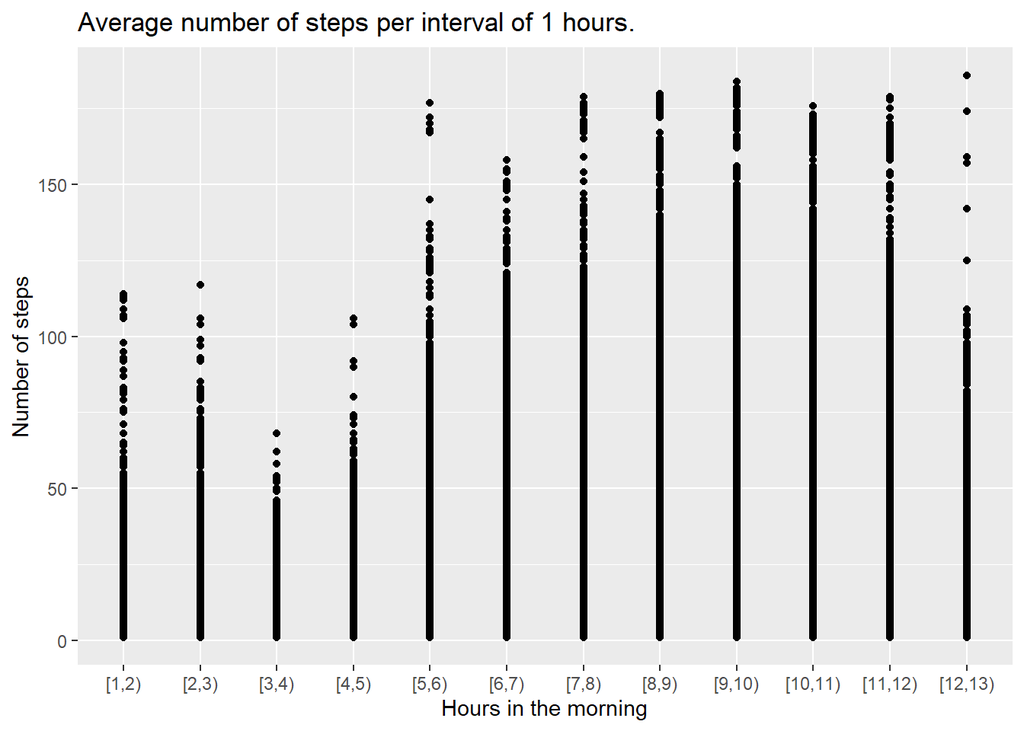

```r
  #summarize(mean_steps = mean(Steps))

ggplot(data = steps_per_hour_AM, aes(x = hour_interval, y=Steps)) +
  #geom_bar(stat = "identity", fill="blue") +
  geom_point()+
  labs(title = "Average number of steps per interval of 1 hours.",
       x = "Hours in the morning",
       y = "Number of steps")
```

```r
steps_per_hour_PM <- steps_filtered %>%
  mutate(hora = hms(hora)) %>%
  mutate(hour_interval = cut(hour(hora), breaks = seq(0, 24, by = 1), right = FALSE)) %>%
  group_by(hour_interval) %>%

  filter(am_pm == "PM") %>%
  select(hora,Steps,am_pm)
```

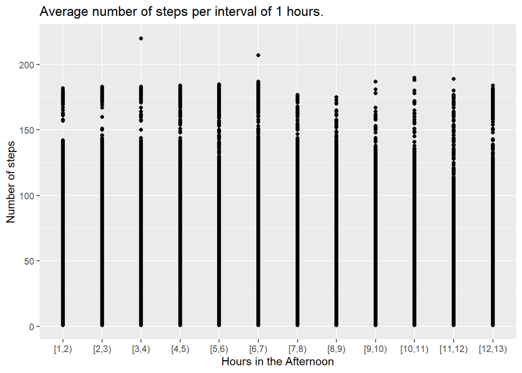

```r
  #summarize(mean_steps = mean(Steps))

ggplot(data = steps_per_hour_PM, aes(x = hour_interval, y=Steps)) +
  #geom_bar(stat = "identity", fill="blue") +
  geom_point()+
  labs(title = "Average number of steps per interval of 1 hours.",
       x = "Hours in the Afternoon",
       y = "Number of steps")
```

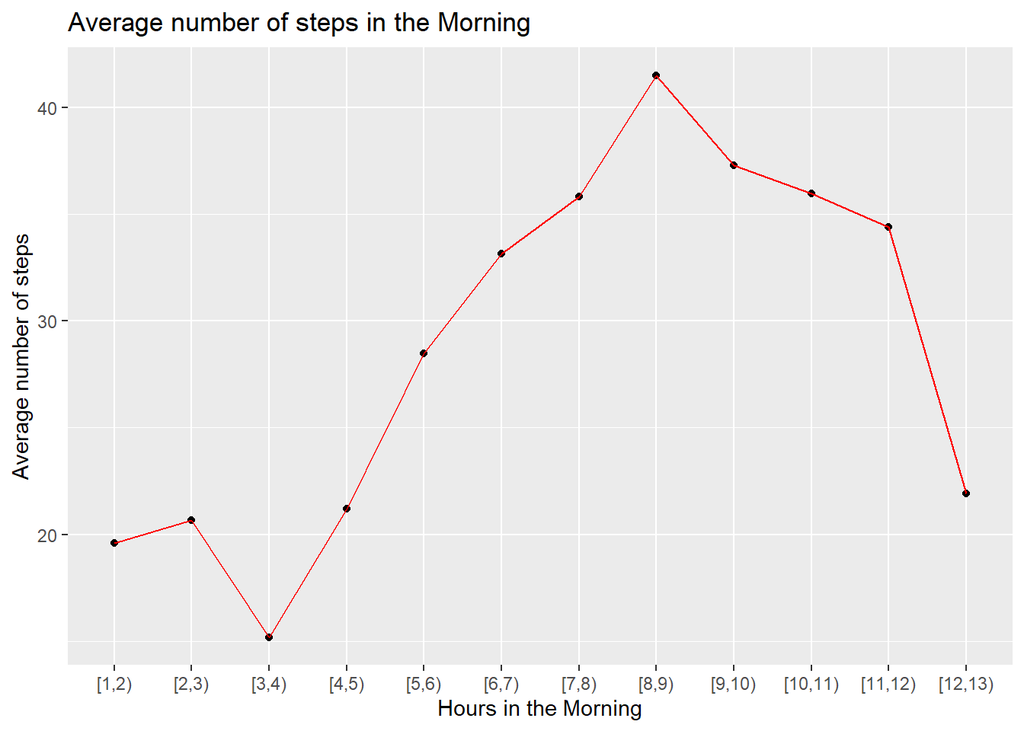

```r
steps_mean <- steps_filtered %>%
  mutate(hora = hms(hora)) %>%
  mutate(hour_interval = cut(hour(hora), breaks = seq(0, 24, by = 1), right = FALSE)) %>%
  group_by(hour_interval) %>%
  filter(am_pm == "AM") %>%
  summarize(promedio = mean(Steps))

ggplot(data = steps_mean, aes(x = hour_interval, y=promedio, group=1)) +
  #geom_bar(stat = "identity", fill="blue") +
  geom_point()+
  geom_line(colour="red")+
  labs(title = "Average number of steps in the Morning",
       x = "Hours in the Morning",
       y = "Average number of steps")
```

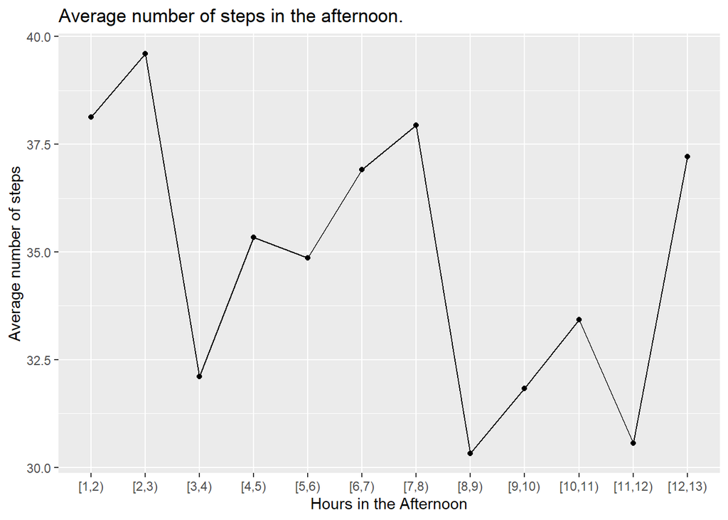

```r
steps_mean <- steps_filtered %>%
  mutate(hora = hms(hora)) %>%
  mutate(hour_interval = cut(hour(hora), breaks = seq(0, 24, by = 1), right = FALSE)) %>%
  group_by(hour_interval) %>%
  filter(am_pm == "PM") %>%
  summarize(promedio = mean(Steps))

ggplot(data = steps_mean, aes(x = hour_interval, y=promedio, group=1)) +
  #geom_bar(stat = "identity", fill="blue") +
  geom_point()+
  geom_line()+
  labs(title = "Average number of steps in the afternoon.",
       x = "Hours in the Afternoon",
       y = "Average number of steps")
```

#### **Calories analysis**

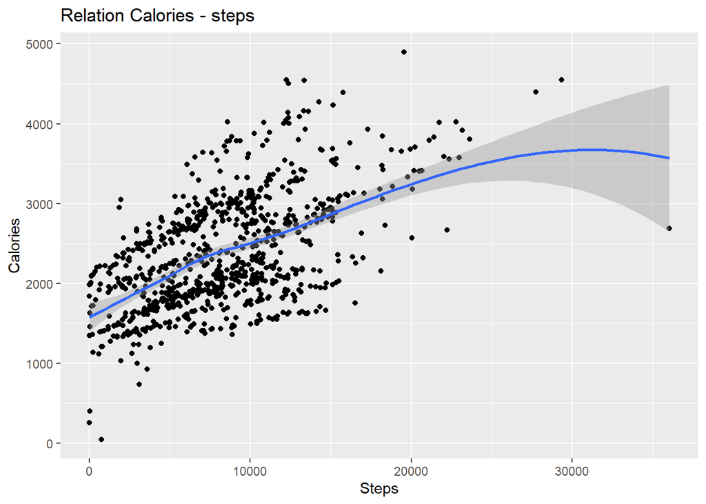

```r
d_activity_c_s <- d_activity %>%
  filter(TotalSteps > 0)
  ggplot(data=d_activity_c_s, aes(x=TotalSteps,y=Calories))+
    geom_point()+
    geom_smooth()+
    labs(title="Relation Calories - steps",
         x="Steps")
```

**There is a direct positive correlation between the number of steps taken during the day and the amount of calories burned. In other words, the more steps a person takes, the more calories they are likely to lose.**

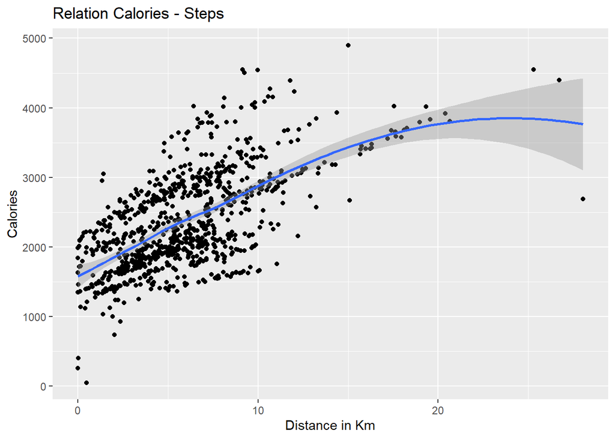

```r
d_activity_c_s <- d_activity %>%
  filter(TotalSteps > 0)
  ggplot(data=d_activity_c_s, aes(x=TotalDistance,y=Calories))+
    geom_point()+
    geom_smooth()+
    labs(title="Relation Calories - Steps",
         x= "Distance in Km")
```

**Similar to the previous point there is a positive relation between the distance a person walk and the number of calories they burn. In other word, the farther a person walks, more calories lose.**

#### **Efficiency Active Distance**

```r
# Separate date
intensities_narrow$ActivityDate <- sapply(strsplit(intensities_narrow$ActivityMinute, " "), "[[", 1)
intensities_narrow$hora <- sapply(strsplit(intensities_narrow$ActivityMinute, " "), "[[", 2)
intensities_narrow$am_pm <- sapply(strsplit(intensities_narrow$ActivityMinute, " "), "[[", 3)
```

```r
# filter columns
filter_dactivity_c_s <- d_activity_c_s %>%
  select(Id, ActivityDate, Calories)
```

```r
# merge data
intensity_merge <- inner_join(intensities_narrow,filter_dactivity_c_s, by=c("Id","ActivityDate"))
```

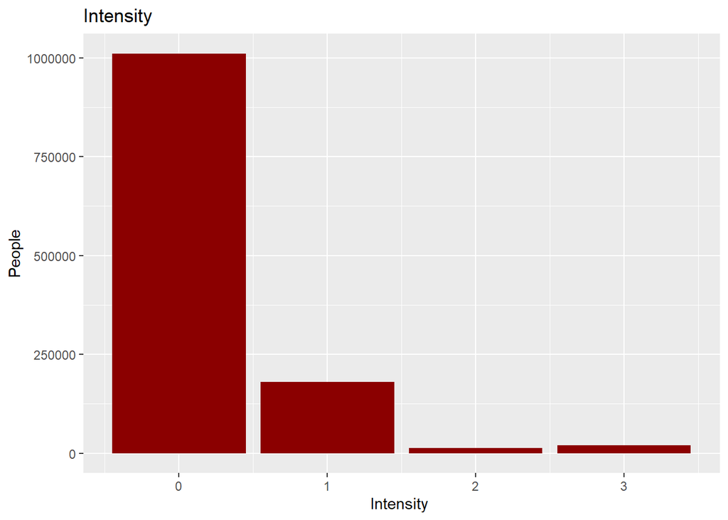

```r
int_0 <- intensity_merge %>%
  group_by(Intensity, Id, Calories) %>%
  #group_by(Intensity) %>%
  #unique(Id)%>%
  count() %>%
  ungroup()


ggplot(data=int_0, aes(x=Intensity,y=n, fill= Id))+
  geom_bar(stat="identity",fill= "darkred")+
  #geom_smooth()+
  labs(title="Intensity",
       x="Intensity ",
       y="People")
```

**Clients are categorized into four types of intensity levels, with Sedentary (0) being the most prevalent. On the other hand, Light (1) and Very active (3) represent the active activities.**

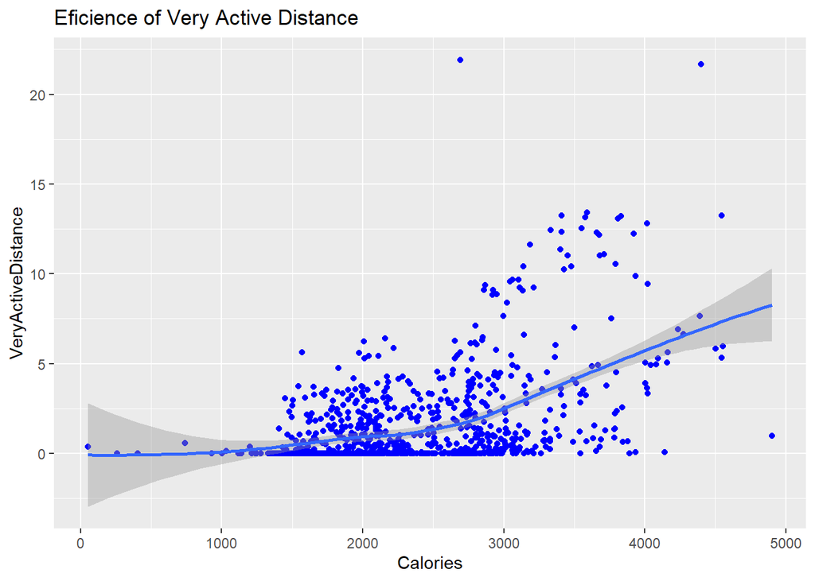

```r
d_activity_c_s <- d_activity %>%
  filter(TotalSteps > 0)
  ggplot(data=d_activity_c_s, aes(x=Calories,y=VeryActiveDistance))+
    geom_point(color="blue")+
    geom_smooth()+
    labs(title="Eficience of Very Active Distance ")
```

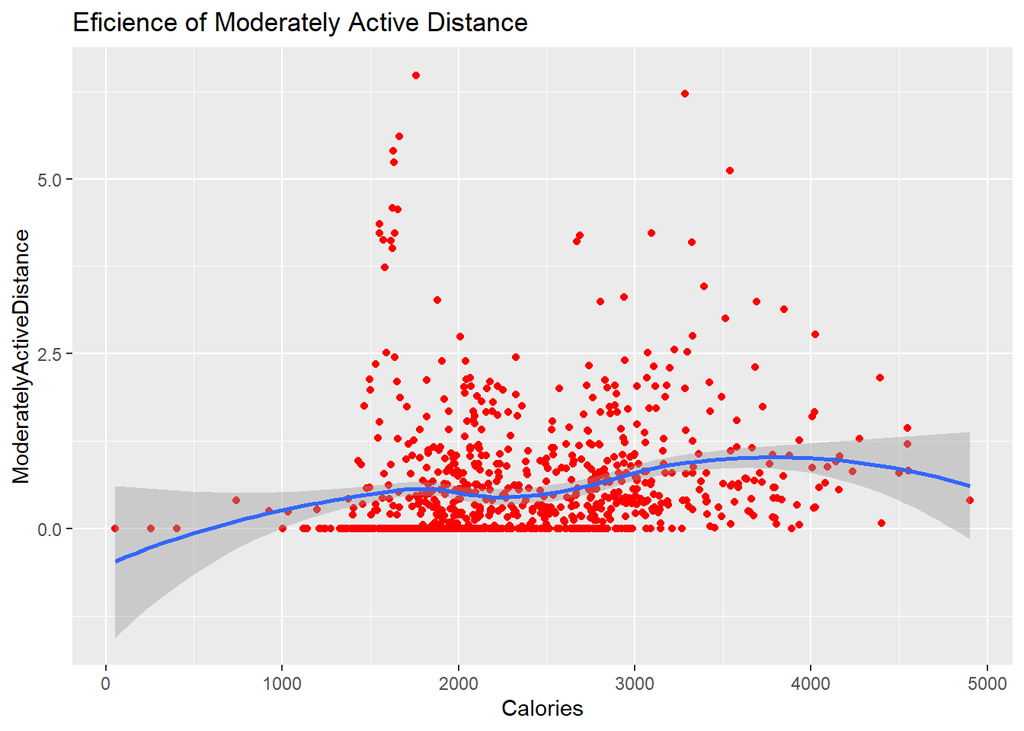

```r
# plot
d_activity_c_s <- d_activity %>%
  filter(TotalSteps > 0)
  ggplot(data=d_activity_c_s, aes(x=Calories,y=ModeratelyActiveDistance))+
    geom_point(color="red")+
    geom_smooth()+
    labs(title="Eficience of Moderately Active Distance ")
```

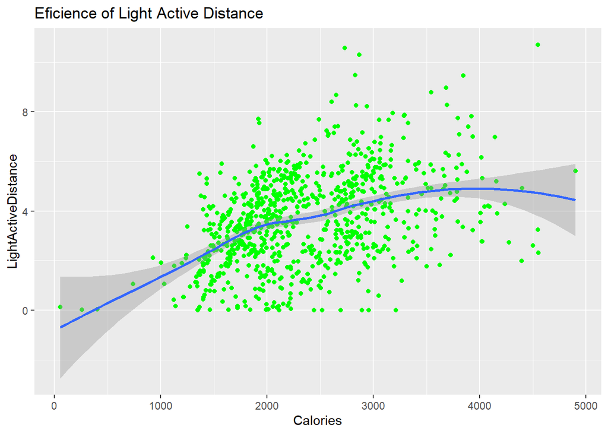

```r
d_activity_c_s <- d_activity %>%
  filter(TotalSteps > 0)
  ggplot(data=d_activity_c_s, aes(x=Calories,y=LightActiveDistance))+
    geom_point(color="green")+
    geom_smooth()+
    labs(title="Eficience of Light Active Distance ")
```

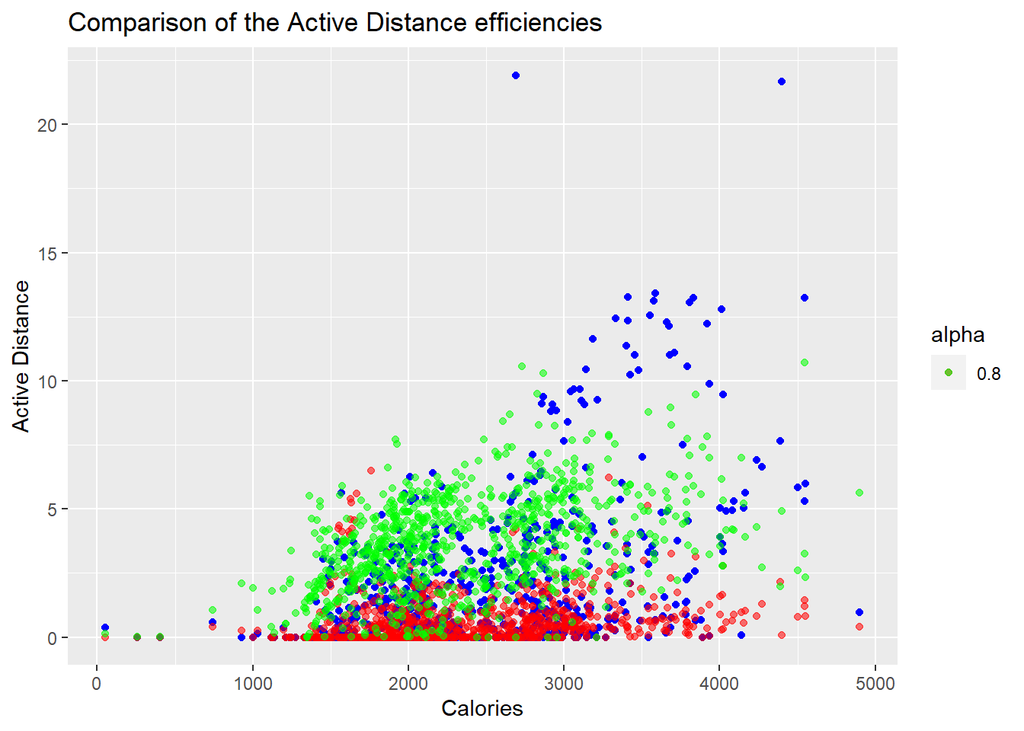

```r
p <- ggplot(data=d_activity_c_s, aes(x = Calories)) +
  geom_point(aes(y = VeryActiveDistance), color = "blue")
p <- p + geom_point(aes(y = ModeratelyActiveDistance, alpha=0.8), color = "red")
p <- p + geom_point(aes(y = LightActiveDistance, alpha=0.8), color = "green")+
    labs(title="Comparison of the Active Distance efficiencies", y="Active Distance")
p
```

**I visualize the impact of various types of activities on calorie expenditure**

### **Sleep analysis**

**Dividing the column “Total Minutes Asleep”**

```r
sleep_filtered <- sleep_clean %>%
                  filter(TotalMinutesAsleep > 0)
sleep_filtered$fecha <- sapply(strsplit(sleep_filtered$SleepDay, " "), "[[", 1)
sleep_filtered$hora <- sapply(strsplit(sleep_filtered$SleepDay, " "), "[[", 2)
sleep_filtered$am_pm <- sapply(strsplit(sleep_filtered$SleepDay, " "), "[[", 3)
```

**Creating new column summarazing information of all active minutes**

```r
filter_activity_ <- d_activity %>%
  mutate(activity_minutes =VeryActiveMinutes + FairlyActiveMinutes + LightlyActiveMinutes )
  df1 <- rename(filter_activity_, fecha = ActivityDate)
```

**Selecting useful columns for the analysis**

```r
df2 <- df1 %>%
  select(Id,fecha,activity_minutes,SedentaryMinutes,Calories)
```

**Merging Data frames**

```r
sleep_merge <- inner_join(sleep_filtered,df2, by=c("Id","fecha"))
```

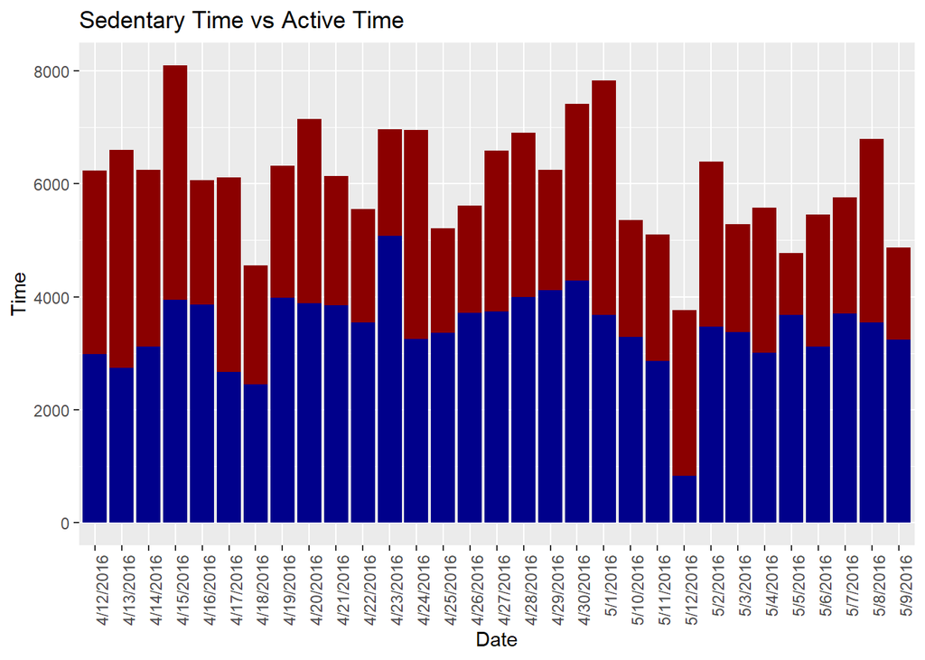

```r
sleep_ac_slep<-sleep_merge %>%
  select(fecha,TotalMinutesAsleep,TotalTimeInBed,activity_minutes)

ggplot(data = sleep_ac_slep, mapping = aes(x = fecha)) +
  geom_histogram(aes(y = TotalTimeInBed), fill = 'darkred',stat = "identity") +
  geom_histogram(aes(y = activity_minutes), fill = 'darkblue', stat = "identity") +
  labs(title = "Sedentary Time vs Active Time",
       x = "Date",
       y = "Time") +
  theme(axis.text.x = element_text(angle = 90, hjust = 1)) #hjust =1 ajusta el texto
```

```r
# aqui tengo que poner la suma de las actividades
d_activity_c_s$SumAct <- d_activity_c_s$VeryActiveMinutes + d_activity_c_s$FairlyActiveMinutes + d_activity_c_s$LightlyActiveMinutes
```

```r
summary(d_activity_c_s$SumAct)
```

```
##    Min. 1st Qu.  Median    Mean 3rd Qu.    Max.
##     0.0   182.5   258.0   247.8   323.0   552.0
```

```r
summary(d_activity_c_s$SedentaryMinutes)
```

```
##    Min. 1st Qu.  Median    Mean 3rd Qu.    Max.
##     0.0   721.5  1021.0   955.8  1189.0  1440.0
```

**Looking the information and comparing Sedentary minutes and Active Minutes the average between both are:**

1. Sedentary Minutes: 955.8 minutes
2. Active Minutes: 247.8 minutes

## **Findings**

After analysing the data, the following insights would help influence Bellabeat Marketing strategy:

  ○ Total Steps: 7816

  ○ Active Distance: 1.54 km

  ○ Sedentary Minutes: 978.6 min - 16.3 hrs

  ○ Time in bed: 458.5 min - 7.64 hrs

  ○ Heart rate: 77.33 beats per minute

## **Recommendations**

The Bellabeat app is a comprehensive tool that helps women enhance both their personal and professional lives by promoting healthy habits and providing personalized recommendations for daily routines. For instance:

1. To help clients achieve their weight loss goals, the app can calculate the number of calories burned per day and send progress updates to the user.
2. The app offers customized scheduling recommendations for activities such as sleep, exercise, and work. It also provides guidance on how to break bad habits.
3. If the wellness tracker detects that a user is having trouble sleeping, the app offers tutorials on how to sleep better.
4. The app provides the equivalent walking distance needed based on the type of active distance recorded (Light, Moderate, Active).
5. Bellabeat encourages physical activity through various events and activities.